# Predicting Graduate Prospects

Avision Ho (a_vision@hotmail.co.uk)

17 February 2018

# Author’s Note

1. DISCLAIMER: The author is relatively new to **Bayesian statistics**, so would appreciate suggestions and tips.
2. To pull in the packages used for this project, run `packrat::snapshot` in your console to install the relevant packages.
3. Key lesson learnt here is that in most cases, you should do a piece of analysis *“well enough”*, so that it does not necessarily need to be perfect. However, when attempting to communicate a new concept in a way that people, especially analysts interested in the details and process, understand in a clear, concise and succint manner, as well as encouraging them to try out the concept, then extra time, effort and thought must go to doing more than *“well enough”*.
4. In this regard, your humble author has tried their best to ensure that the language is crystal-clear, the code is as readable as possible, the naming conventions are immediately obvious as to how wha they represent, and it is all consistent.
5. Nevertheless, your humble author would be most grateful to receive feedback, questions, and suggestions on how this analysis and report can be improved further. Feel free to get in touch either via the [GitHub page](https://github.com/avisionh/Predict-Graduate-Prospects), or via email. 🙇🏼
6. Please do let this author know if this analysis has encouraged you to try **Bayesian statistics** yourself. Your author would be most delighted to see it being implemented more widely.😄

# Executive Summary

7. **Bayesian statistics** is a fundamentally different way of viewing, approaching, and tackling stastitical problems. It involves thinking about situations from a probabalistic viewpoint.
8. Contrast this with the other main competing school of statistical thought, **frequentist statistics**, which views situations within the context of repeated events.
9. These differences manifest themselves in the actual statistical techniques applied to problems, with **multi-linear regression** being the technique considered in this paper. For each school-of-thought, there is a different way to carry out the statistical technique.
10. Whereas in most cases, the results of these models should broadly align irrespective of whether you apply a **frequentist** or **Bayesian** version of a statistical technique, the way you interpret and communicate these results are different.
11. **Bayesian** interpretations of results fall more in-line with how we intuitively think about problems.

# Motivating Example

12. Alan Turing, mathematician, computer scientist, and one of the forebearers of modern computers; led efforts to unravel the German Enigma code - a development that helped the Allies win the Second World War. Turing employed several technologies and techniques in his work, including Banburismus, a process he invented which used sequential conditional probability to infer information about the likely settings of the Enigma machine.
13. Banburismus is described as *‘a highly intensive, Bayesian system’* that allowed Turing and colleagues to guess a stretch of letters in an Enigma message, measure their belief in the validity of these guesses - using Bayesian methods to assess the probabilities - and add more clues as they arrived.
14. Therefore, if it is good enough for Turing, and it is good enough to win a world war, then it must be good enough for us… 💁🏻

# Section 1: Introduction

## Motivation

15. The purpose of this paper is to investigate the use of **Bayesian statistics** for forecasting the graduate prospects of *first-degree students* studying full-time.[^1]
16. We will compare our outputs of applying a **frequentist** against a **Bayesian multi-linear regression** using **k-fold cross-validation**.
17. By the end, I hope to have provided to you with a gentle and accessible introduction to what **Bayesian statistics** is, how it is different to **frequentist statistics**, the benefits of thinking and viewing problems from a **Bayesian** perspective, and above all, show how you can practically implement **Bayesian statistics** in your own work. Hopefully, I can show that it is not rocket-🔬. 😉

## Caveats

18. As we will remove *sex* and other highly-correlated variables with *sex* from our model, then the predictive accuracy of our model may not be optimal. This to ensure we meet [GDS Ethics Framework](https://www.gov.uk/government/publications/data-science-ethical-framework) standards.
19. There are four forms of *“The Open University”*, one for each UK region, in our *data_qualifiers* dataframe. Will need to check if this is the case for our other data frames.
20. As we have chosen only one **fuzzy-matching** algorithm, and have not benchmarked this against other possible algorithms, then our data matching between HESA SFR and Complete University’s Guide data may not be optimal. To improve our data matching and consequently, our model performances, we should explore alternative **fuzzy-matching** algorithms.
21. Have not performed analysis on all possible independent variables such as *first-degree full-time student count*, *Entry standards*, *Research intensity* etc., so we could meaningfully improve our model fit by including these.
22. From transforming our dataframes so that they are of *double* datatype, the conversion for *‘Acad Services Speeds’* failed, so we generated NAs. Whils this does not affect the analysis as we have not used this data, it is something worth bearing in mind for future analysis.

# Section 2: Core Concepts

## Bayesian Stastistics

### What is it?

23. **Bayesian statistics/inference** is a fundamentally different way to view and approach statistical problems/questions. At its simplest, it boils down to **Bayes’ Theorem** within probability theory:
    $$(1)\quad P(A\mid B\,) = {\frac {P(B\mid A)\ P(A\,)}{P(B\,)}}$$
    $$where\:A\:and\:B\:are\:events\:and\:P(B)\neq 0$$
24. **Bayesian inference** follows what is recognised as rational learning; where we combine observational evidence with pre-existing beliefs to obtain new beliefs. In this way, the role of data in statistics is evidentiary and henceforth we can formulate **Bayesian inference** to be:
    $$(2)\quad Beliefs\: after\: observation\: =\: Beliefs\: before\: observation\: +\: total\: evidence\: observed$$
25. For the purpose of terms used later in this paper, we will rephrase (2) as (3) below:
    $$(3)\quad Posterior\: beliefs\: \propto\: Prior\: \times\: Likelihood$$

### Frequentist versus Bayesian Statistics

26. **Frequentist/classical statistics**, which is widely learnt in education and practiced in industry, is distinct from **Bayesian statistics** on a philosophical level. The two schools of thought view the concept of probability in fundamentally different ways. [^2]
27. Most **frequentist** methods have a **Bayesian** equivalent, and they both generally lead to broadly similar results. Therefore, one’s choice in deciding which of the two approaches to take is based on principle on how one views the problem, and seeks to interpret the answers. We will illustrate this with an example below: [^3]

> **Scenario:** You have misplaced your phone somehwere in the house. You thus decide to call your phone so you can use the ringing to direct you to where it is. [^4]

> **Frequentist reasoning** - You hear your phone ringing and have a mental model of your house that helps you identify the area from which the ringing is coming from. Therefore, upon hearing the ringing, you infer the area of your house that you must search to locate your phone.

> **Bayesian reasoning** - You hear your phone ringing. In addition to having a mental model of your house, you also know the locations where you have misplaced your phone in the past. Therefore, you combine the inferences from the ringing and your prior knowledge of where you have misplaced your phone in the past to identify an area you must search to locate your phone.
28. Formally fleshing out this example, the differences between **frequentist** and **Bayesian** statistics is summarised in the table below.

| Frequentist inference | Bayesian inference |
| --- | --- |
| - Data are a repeatable random sample, so studies can be reapeated. | - Data are observed froma realised sample, so studies are fixed. |
| - Underlying parameters being observed remain constant during this repeatable process. | - Underlying parameters are unknown and desvribed probabilisitcally, so can vary. |
| - Parameters are fixed. | - Data are fixed. |

29. This distinction in how parameters and data are viewed between **frequentists** and **Bayesians** is seen in how **confidence intervals** and **credible intervals** are interpreted respectively.

> A frequentist would say that over repeated sampling of 95% confidence intervals, 95% of these confidence intervals have the true parameter lying in them.

> A Bayesian would say over one 95% credible interval, the probability the parameter of interest will lie within this interval is 95%.
30. In this way, a **Bayesian** inference lends itself better to interpretation as it is more intuitive, and on a practical level, we typically do not have time/money to collect data repeatedly. [^5]

## k-fold Cross validation

### What is it?

38. **Cross-validation** is a technique to evaluate a model’s predictive power by partitioning the data into a **training set** to train the model, and a **test set** to evaluate the model’s accuracy in making predictions.
39. **k-fold cross-validation** is a form of **cross-validation** that takes *k* randomly paritioned sub-samples of your data; *k-1* of these sub-samples then act as the **training set** to train your model, with the other sub-sample being used as your **test set** to evaluate your models performance.
40. This process is repeated *k* times so that each of your *k* sub-samples are used for training and testing/evaluating your model. The *k* results you generate from running these *k* models are then averaged to produce a single estimation/metric of how accurate your model is.
41. **k-fold cross-validation** is powerful because it allows you to use all your data for both training and testing purposes. However, it can be computationally expensive.
42. We will use **k-fold cross-validation** to run our **multi-linear regression** models to ensure our model does not *overfit* our data. By *overfitting*, we mean the model is too good at predicting the outputs, *Graduate Prospects 2018*, from our dataset, and cannot accurately predict the our output, *Graduate Prospects 2018*, on new data that is not included in our dataset.

## Root Mean Square Error (RMSE)

43. **Root-mean-square error** is a metric for evaluating the performance of your predictive model. The lower value means that your model is more accurate in producing predictions that are closer to the observed values.
44. It is the differences between predicted values of your model against the values actually observed. Mathematically, this is formulated by the below equation:
    $$RMSE = \sqrt{\frac{\sum_{i=1}^n\left( \hat{y_i}-y_i \right)^2}{n}}$$
45. The **RMSE** can be used to compare the performance of difference models to see which one is more accurate in making predictions of an dependent variable.
46. However, the **RMSE** is scale-dependent, so it cannot be used to compare models on different sets of data, or on models that are based on the same data but the data for each model have different scales. *e.g. one model may be based on income data, whilst the other model is based on income data that is log-transformed.*
47. We will use **RMSE** to evaluate the performance of our **frequentist** and **Bayesian multi-linear regression** models to compare which model gives us more accurate predictions.

# Section 3: Data

## Sources

48. The data used in this project comes from the Higher Educations Standards Agency’s (HESA) Statistical First Release (SFR247) and the Complete University Guide’s university rankings table.
49. In particular, the following datasets are used:
    - [2018 Graduate Prospects](https://www.thecompleteuniversityguide.co.uk/league-tables/rankings?v=wide&y=2018)
    - [2017 Student-Staff Ratios, Academic Services Spend, Good Honours, Facility Spend](https://www.thecompleteuniversityguide.co.uk/league-tables/rankings?v=wide&y=2017)
    - [2017 Degree Classification](https://www.hesa.ac.uk/data-and-analysis/students/table-16.csv)
    - [2017 Subject studied](https://www.hesa.ac.uk/data-and-analysis/students/table-19#note)
    - [2017 Region from](https://www.hesa.ac.uk/data-and-analysis/students/table-1.csv)
    - [2017 Postgraduate/Undergraduate figures](https://www.hesa.ac.uk/data-and-analysis/students/table-1.csv)
    - [2017 Sex](https://www.hesa.ac.uk/data-and-analysis/students/table-1.csv)
    - [2017 Size of full-time population](https://www.hesa.ac.uk/data-and-analysis/students/table-1.csv)
    - [2017 Under-represented group size](https://www.hesa.ac.uk/data-and-analysis/ukpis/widening-participation/table-t1)
50. We will investigate the use of these data sources as potential *predictors* for the graduate prospects of university students.
    - Aligning with the [GDS Ethics Framework](https://www.gov.uk/government/publications/data-science-ethical-framework), we will include *sex* in our variables to measure correlations with other predictors in the model, and if there is a high correlation, we will remove those predictors from our model. This is because *sex* is a protected characteristic, and therefore we should refrain from including it nor any potential proxies for it into our model. The risk of including it in our model is that if the outputs are used for decision-making, then one member of the sex may be unfairly disadvantaged.

## Cleaning

51. Whilst our HESA SFR data has a unique identifier field, *UKPRN*, that we can use to join disparate HESA SFR data together, our Complete University’s Guide web-scraped HTML table does not have such a similar unique identifer field. Instead, it’s unique identifer field is *Name*, which is the universtiy’s name and is of string data type.
52. Our HESA SFR data also has a similar field, *HE provider*, which allows us to join the HESA SFR with the Complete University’s Guide data together. However, given that these fields are of string data type, then we will need to do some data cleaning first as there is a lot of noise in string/text data. The steps we will take to cleaning text data are:
- Convert text to lower case
- Remove numbers and punctuation
- Remove English stopwords *e.g. “the”, “is”, “of”*
- Remove white spaces
- Stem text *e.g. remove the “ed” from “changed”*
53. Once we have cleaned our string columns so they can be matched more accurately, we will then need to apply **fuzzy-matching** to join the HESA SFR data to our Complete University’s Guide data. This is because the two sources may call the same university different names.
- *Example: HESA SFR has “The University of Cambridge” whilst the same university is just “Cambridge” in the Complete University’s Guide data.*
54. Possible fuzzy-matching techniques/algorithms are:
- **Jaro-distance** |
- **Jaro-Winkler distance** |
- **Jaccard distance** |
- **Cosine distance** |
- **Longest common substring** |
55. The particular fuzzy-matching used will be **Longest Common Subsequence**. The reasons for choosing this are outlined below:

| Works well for | Struggles with |
| --- | --- |
| + Missing words | - Ordering |
| + Typos | - Generic wording |

56. In the code below, we demonstrate how to apply text cleaning and fuzzy-matching. Note however that the code is not representative of the code actually used to clean our dataframes. For the actual code, the reader should refer to the underlying R scripts which underpin this report.

```r
# Clean text data
x <- Corpus(VectorSource(x = `name`)) %>%
        tm_map(content_transformer(tolower)) %>%
        tm_map(removeNumbers) %>%
        tm_map(removeWords, stopwords("english")) %>%
        tm_map(removePunctuation) %>%
        tm_map(stripWhitespace) %>%
        tm_map(stemDocument) %>%
        # Remove additional stopwords of "The University of" to get
        # HESA SFR uni names in line with Complete University's Guide
        tm_map(removeWords, c("The University of"))
# Convert Corpus to dataframe
x <- data.frame(Name = sapply(X = x, FUN = as.character), stringsAsFactors = FALSE)

# Fuzzy-matching
# Create grid of names to match - get all permutations
temp <- expand.grid(data_hesa$Name, data_CUG$Name) %>%
          rename(`hesa_name` = `Var1`, `CUG_name` = `Var2`) %>%
          arrange(`hesa_name`)
# Use Longest Common Subsequence (LCS) algorithm
temp$dist_lcs <- stringdist(temp$hesa_name, temp$CUG_name, method = "lcs")
# Rank the LCS distances  smaller the better
temp <- temp %>%
          transform(rank_dist_lcs = ave(`dist_lcs`, `hesa_name`,
                                        FUN = function(x) rank(x, ties.method = "first"))) %>%
          # Take only the best rank
          filter(rank_dist_lcs == 1) %>%
          # From visual inspection of matches, any fields with dist_lcs > 8 seem to be wrong,
          # with exception of LSE
          filter(dist_lcs <= 8 | `CUG_name` == "london school econom")

# temp dataframe thus acts as lookup table joining
# data_hesa to data_CUG
data_master <- temp[, c("hesa_name", "CUG_name")] %>%
                left_join(y = data_hesa, by = c("hesa_name" = "Name")) %>%
                left_join(y = data_CUG, by = c("CUG_name" = "Name"))
```

57. We have now cleaned and joined our separate datasets together. The complete dataframe looks as follows:

```r
glimpse(data_master)
```

```
## Observations: 121
## Variables: 24
## $ UKPRN                     <int> 10007783, 10007856, 10007857, 100053...
## $ `HE provider`             <chr> "The University of Aberdeen", "Abery...
## $ `Country of HE provider`  <chr> "Scotland", "Wales", "Wales", "North...
## $ `Region of HE provider`   <chr> "All", "All", "All", "All", "All", "...
## $ `FD FT student count`     <int> 9725, 5985, 7835, 14725, 19145, 7950...
## $ `PG FT student count`     <int> 2530, 600, 1510, 3055, 5240, 1240, 1...
## $ `Male Female ratio`       <dbl> 0.7795059, 1.1130742, 0.7380688, 0.8...
## $ `EU to non-EU ratio`      <dbl> 14.677419, 22.920000, 9.109677, 13.8...
## $ `Pass Fail ratio`         <dbl> 2.1759259, 2.0714286, 2.2424242, 2.9...
## $ `STEM non-STEM ratio`     <dbl> 0.76379691, 0.58199357, 0.80392157, ...
## $ `State Private ratio`     <dbl> 79.6, 95.2, 95.8, 98.1, 85.3, 94.9, ...
## $ Rank                      <chr> "42nd", "87th", "62nd", "33rd", "35t...
## $ `Entry Standards`         <dbl> 441, 289, 342, 385, 399, 315, 426, 3...
## $ `Student Satisfaction`    <dbl> 4.00, 4.01, 4.26, 4.13, 4.09, 4.03, ...
## $ `Research Quality`        <dbl> 2.97, 2.84, 2.99, 2.99, 3.27, 3.00, ...
## $ `Research Intensity`      <dbl> 0.73, 0.76, 0.63, 0.95, 0.62, 0.09, ...
## $ `Stu-Staff Ratio`         <dbl> 13.5, 19.1, 16.9, 15.1, 13.7, 17.9, ...
## $ `Acad Services Speeds`    <dbl> NA, NA, NA, NA, NA, NA, NA, 887, NA,...
## $ `Facilities Spend`        <dbl> 672, 548, 442, 748, 535, 711, 386, 3...
## $ `Good Honours`            <dbl> 77.9, 66.9, 64.2, 78.3, 76.0, 67.5, ...
## $ `Degree Completion`       <dbl> 84.3, 88.6, 82.3, 92.6, 92.6, 82.3, ...
## $ `Overall Score`           <dbl> 718, 555, 629, 754, 747, 598, 747, 5...
## $ `Graduate Prospects 2017` <dbl> 76.0, 62.3, 67.2, 78.4, 79.8, 59.0, ...
## $ `Graduate Prospects 2018` <dbl> 78.6, 67.9, 66.1, 80.5, 72.3, 70.0, ...
```

# Section 4: Data Exploration

## Missing Values

58. To obtain an idea of how many missing/NA values we have, we plot for each variable in our cleaned and joined dataset, which observations/row index has an NA value, coloured grey. In the plot below, we see that we have very little missing data *(0.04)* so we do not need to consider data imputation methods like **bootstrap aggregation** (*bagging*).

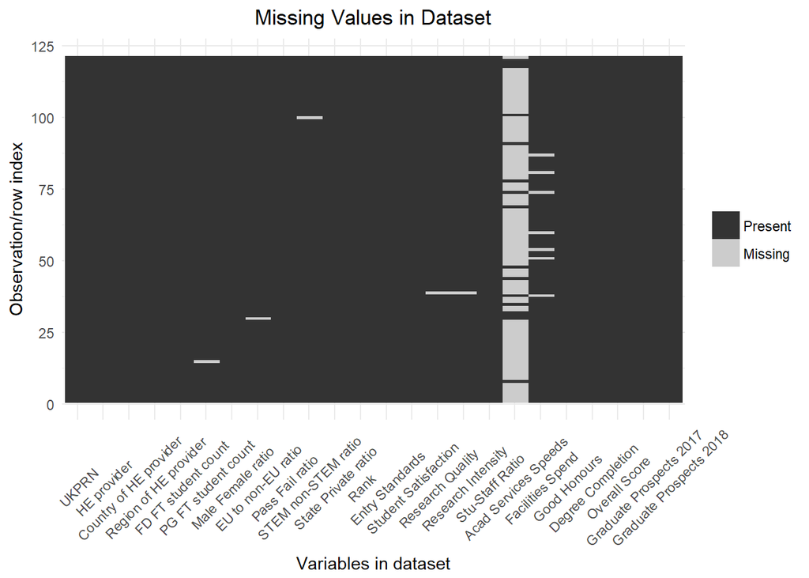

```r
func_plotNAs(data_master)
```

## Dependent Variable: Graduate Prospects

59. In the plot below, we have the distribution of *Graduate Prospects 2018* scores. We see that it follows a general normal distribution. Given this, we can see that there are values at both tails away from the distribution, which may be candidate outlier observations which should be iinvestigated further to see if they are actually outlier points, and henceforth should be removed from our dataset. This is because the presence of outliers can adversely impact our **linear regression**.

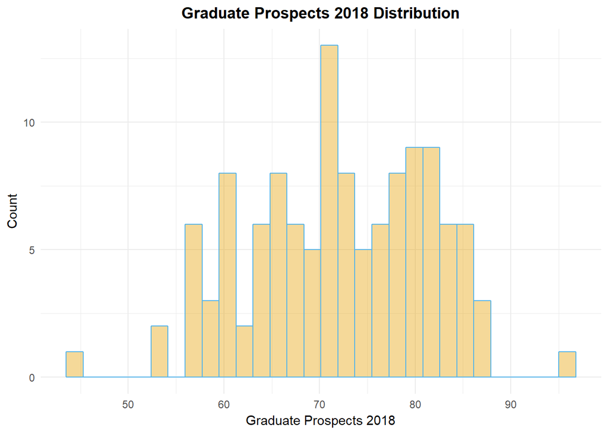

```r
ggplot(data = data_master, mapping = aes(`Graduate Prospects 2018`)) +
  geom_histogram(fill = "#E69F00", colour = "#56B4E9", alpha = 0.4) +
  labs(title = "Graduate Prospects 2018 Distribution", x = "Graduate Prospects 2018", y = "Count") +
  theme_minimal() +
  theme(plot.title = element_text(face = "bold", hjust = 0.5))
```

```r
x = mat_corrDV
```

## Independent Variables

61. From the plot below, we have the correlation of each independent variable against other independent variables. It is important to ensure that our independent variables are not highly correlated with sex in accordance to the GDS Ethics framework. Moreover, we should also remove highly-correlated independent variables because they will negatively affect our regression.
62. From the correlation matrix plot below, we see the following:
- Male-Female ratio is not strongly correlated with any other variables.
- State Private ratio is fairly correlated with PG FT sutdent count and Pass Fail ratio.
- Research Quality is highly correlated with PG FT student count.
- Stu-Staff Ratio is fairly correlated with State Private ratio.

Given this, we will drop the *State Private ratio* and *PG FT student count* variables from our regressions. This is because keeping correlated independent variables will make our regression results inaccurate.

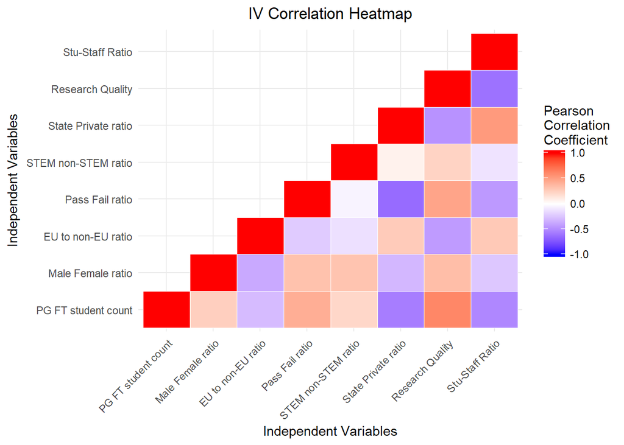

```r
# Correlation heatmap
ggplot(data = mat_corrIV, mapping = aes(x = `Var2`, y = `Var1`, fill = value)) +
  geom_tile(colour = "white") +
  scale_fill_gradient2(low = "blue", high = "red", mid = "white",
                       midpoint = 0, limit = c(-1, 1), space = "Lab", name = "Pearson\nCorrelation\nCoefficient") +
  theme_minimal() +
  theme(plot.title = element_text(hjust = 0.5), axis.text.x = element_text(angle = 45, vjust = 1, hjust = 1)) +
  labs(title = "IV Correlation Heatmap", x = "Independent Variables", y = "Independent Variables")
```

# Section 5: Multi-Linear Regression

## Assumptions

67. When performing a **multi-linear regression**, it is important to check that the regression model satisfies the following assumptions, otherwise the outputs from the model which describe the relationship the independent variables have with the dependent variables will not be statistically valid.
- **A1: Linearity** | the relationship between the independent variables to the dependent variable can be modelled by a linearly, meaning as the independent variables change, the dependent variable should change in a linear/constant rate manner.
- **A2: Normal Distribution** | the dependent variable or **residuals**, which are the deviations of each observed value from the mean dependent variable, are normally distributed.
- **A3: Homoscedasticity** | the **residuals** are **homoscedastic**, meaning the **residual**’s variances are constant across observations.
- **A4: Independence** | the **residuals** are independent from each other, meaning that the value of one **residual** should not affect the value of another **residual**.
- **A5: No multi-collinearity** | the independent variables should not be correlated with each other.
68. For **A4: Independence**, it is less imporant to meet this because we are dealing with non-time series data.
69. Whilst not included as an assumption, the impact extreme observations can have on determing the regression line can be significant, and therefore a robust regression model would remove these observations.

## Frequentist Multi-Linear Regression

70. We build the **frequentist multi-linear regression** model using **k-fold cross-validation** from the code below.

```r
# Set-up 10-fold cross-validation
trainSet <- trainControl(method = "cv", number = 10)
# Run linear regression model
model_regFreq <- train(form = `Graduate Prospects 2018` ~ .,
                       data = mat_reg, trControl = trainSet,
                       method = "lm")
```

### Testing regression assumptions

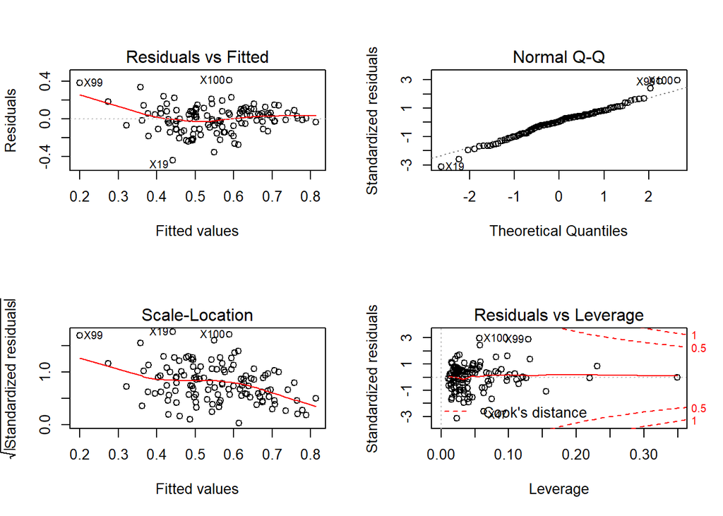

```r
par(mfrow = c(2, 2))
plot(model_regFreq$finalModel)
```

### Interpreting regression model outputs

```r
summary(model_regFreq)
```

```
##
## Call:
## lm(formula = .outcome ~ ., data = dat)
##
## Residuals:
##      Min       1Q   Median       3Q      Max
## -0.44198 -0.08712  0.00567  0.07955  0.41216
##
## Coefficients:
##                             Estimate Std. Error t value  Pr(>|t|)
## (Intercept)                  0.25196    0.08945   2.817   0.00571 **
## `\\`EU to non-EU ratio\\``   0.07749    0.09681   0.800   0.42513
## `\\`Pass Fail ratio\\``      0.20204    0.09746   2.073   0.04040 *
## `\\`STEM non-STEM ratio\\``  0.11506    0.07713   1.492   0.13852
## `\\`Research Quality\\``     0.38478    0.08790   4.377 0.0000266 ***
## `\\`Stu-Staff Ratio\\``     -0.12663    0.09358  -1.353   0.17864
## ---
## Signif. codes:  0 '***' 0.001 '**' 0.01 '*' 0.05 '.' 0.1 ' ' 1
##
## Residual standard error: 0.1428 on 115 degrees of freedom
## Multiple R-squared:  0.4058, Adjusted R-squared:   0.38
## F-statistic: 15.71 on 5 and 115 DF,  p-value: 0.000000000009083
```

### Regression model accuracy

74. The *RMSE* of our **frequentist multi-linear regression** model is 0.14. As we have scaled our data to be in the range [0,1], then this is a small value, hence our model is accurate in predicting *Graduate Prospects 2018*.

```r
ModelMetrics::rmse(actual = model_regFreq$finalModel$model$.outcome,
                   predicted = model_regFreq$finalModel$fitted.values)
```

### Confidence interval

```r
confint(object = model_regFreq$finalModel, level = 0.95)
```

```
##                     2.5 % 97.5 %
## (Intercept)          0.07   0.43
## EU to non-EU ratio  -0.11   0.27
## Pass Fail ratio      0.01   0.40
## STEM non-STEM ratio -0.04   0.27
## Research Quality     0.21   0.56
## Stu-Staff Ratio     -0.31   0.06
```

## Bayesian Multi-Linear Regression

### Framework

76. We will follow the steps below to conduct **Bayesian analysis**:
1. Form **prior distribution** of your dependent variable, *Graduate Prospects*. This can be from an assumption made by the business such as policymakers who have a view of how the dependent variable is distributed, or it can be based on past values of your dependent variable. We use the **fitdistrplus** package for this.
2. Estimate the parameters for your **prior distribution** and see how well your dependent variable fits your **prior distribution**. If it does, proceed further. If it does not, try another common distribution.
3. Use the parameters from your **prior distribution** to specify your **Bayesian model**. We define this model using **BUGS** code (which drives the Gibbs-Sampler) in our *bayesModel.bug* file and use the **runjags** package for this.
4. Run diagnostic tests on your **MCMC** chains to ensure your chains are *representative, accurate and stable, and efficient*.
5. Tune the parameters when running your **Bayesian model** if your **MCMC** chains are not either not *representative, accurate, or stable*. Otherwise, analyse your model outputs!

### Testing regression assumptions

77. Given that our **frequentist multi-linear regression** satisfied the linear regression assumptions, we will assume the **Bayesian multi-linear regression** will also based on the principle that they are using the same dependent and independent variables, and the same data.
78. In this way, we will forego checking the linear regression assumptions.

### Formulating Priors

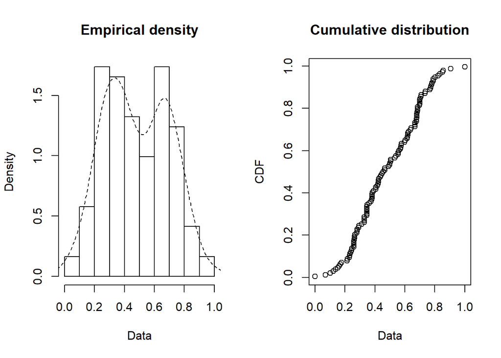

```r
# Graduate Prospects 2017 distribution
plotdist(data = temp, histo = TRUE, demp = TRUE)
```

80. To test our assumption above, we plot the **Cullen and Frey graph** below, which allows us to see what common distribution our dependent variable, *Graduate Prospects 2017*, aligns most closely to.
81. Our dependent variable, *Graduate Prospects 2017*, is the blue dot on the graph, and it is most closest to the triangle and asterisk objects, whilst also lying in the grey region. We will discuss each of these aspects in turn.
- Triangle | The triangle represents the uniform distribution, so by our blue dot, which represents our dependent variable, being close to the triangle object, this means that our dependent variable is close to being uniformly distributed.

$${U}(\alpha,\: \beta)\: where -\infty\: <\: \alpha\: <\: \beta\: <\: \infty$$

- Asterisk | The asterisk represents the normal distribution, so by our blue dot, which represents our dependent variable, being close to the asterisk object, this means that our dependent variable is close to being normally distributed.

$$N(\mu,\: \sigma^2)\: where\: \mu\: \in\: \rm I\!R\: and\: \sigma^2\: >\: 0$$

- Grey region | The grey region represents the beta distribution, so by our blue dot, which represents our dependent variable, being within this grey region, this means there are $\alpha$ and $\beta$ values such that our dependent variable is close to being beta-distributed.

$$B(\alpha,\: \beta)\: where\: \alpha,\: \beta\: >\: 0$$

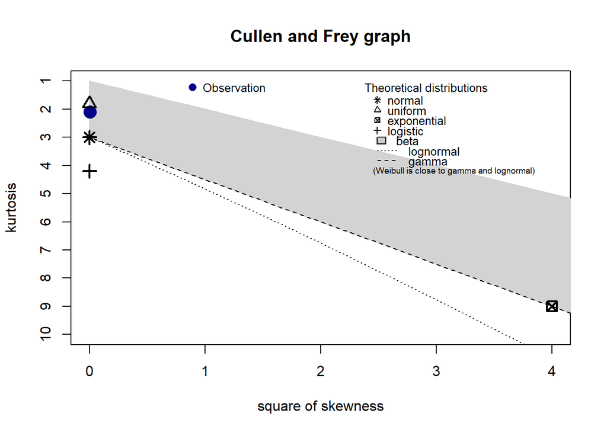

```
## summary statistics
## ------
## min:  0.00000001   max:  1
## median:  0.4547414
## mean:  0.4819571
## estimated sd:  0.2140505
## estimated skewness:  0.07885535
## estimated kurtosis:  2.103885
```

```r
# Graduate Prospects 2017 distribution
descdist(data = temp, discrete = FALSE)
```

```r
# Fit the uniform and normal distributions
fitdist(data = temp, distr = "unif", method = "mme",
                       discrete = F, na.rm = T)
```

```
## Fitting of the distribution ' unif ' by matching moments
## Parameters:
##    estimate
## 1 0.1127459
## 2 0.8511683
```

```r
fitdist(data = temp, distr = "norm", method = "mme",
                       discrete = F, na.rm = T)
```

```
## Fitting of the distribution ' norm ' by matching moments
## Parameters:
##       estimate
## mean 0.4819571
## sd   0.2131642
```

84. In the **goodness-of-fit plots** below, we examine how well our proposed uniform and normal distributions actually fit our dependent variable, *Graduate Prospects 2017*, in more detail.
- The *histogram and theoretical densities* and *empirical and theoretical CDFs* plots on the left-side of the plots below are considered the classical **goodness-of-fit plots**. From these, we can see that both distributions fit our dependent variable, *Graduate Prospects 2017*, very well.
- The *quantile-quantile (Q-Q) plot* in the top-right panel shows that both the uniform and normal distributions provide a good description of the right-tail of our dependent variable’s empirical distribution.
- The *probability-probability (P-P) plot* in the bottom-right panel shows that both the uniform and normal distributions provide a good description of the centre of our dependent variable’s empirical distribution.[^8]

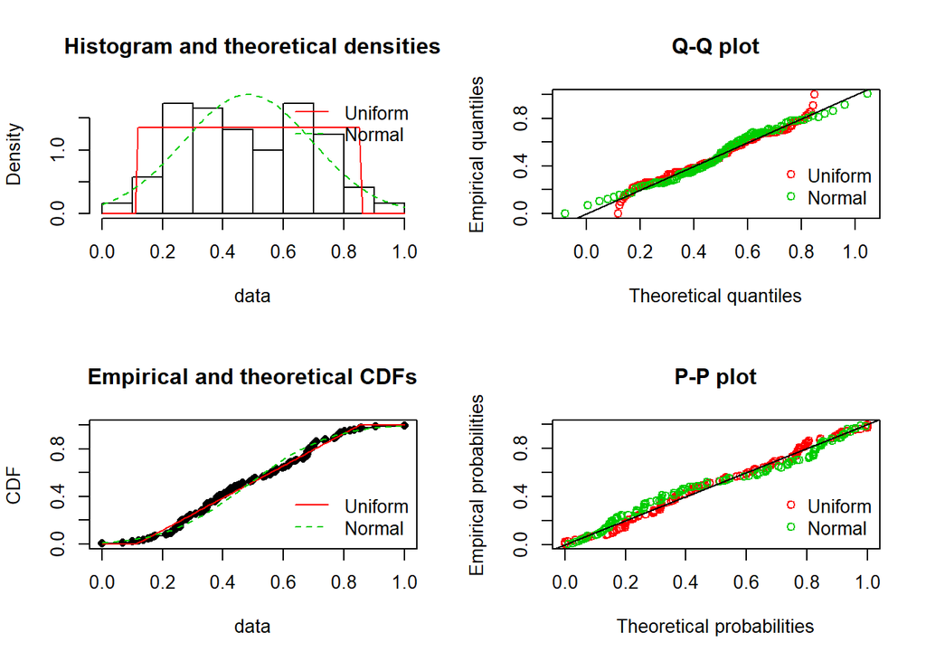

```r
par(mfrow = c(2,2))
func_plotGoF(dist = rpt_dist, titles = name_dist)
```

### Building the Bayesian model

86. We build the **Bayesian multi-linear regression** model using **parallel computing** in the code below.

```r
# create vector of regressuion parameters
vec_regParameters <- "beta0"
len <- ncol(x = mat_reg) - 1
for(i in 1:len) vec_regParameters <- append(x = vec_regParameters, values = paste0("beta[", i, "]"))
numRows <- nrow(mat_reg)
# define DV and IVs for regression
data_regBayes <- list(x = mat_reg[1:numRows, 1:len], y = mat_reg[1:numRows, len + 1])

# run model
model_regBayes <- run.jags(method = "parallel", model = "bayesModel.bug", monitor = vec_regParameters,
          data = data_regBayes, n.chains = 4, summarise = FALSE, plots = FALSE, silent.jags = TRUE)
```

### Markov-Chain Monte Carlo analysis

#### i. Representativeness

89. In the plots below, we have the **trace/time-series plots** of the **MCMCs** run. It shows the values each of our $\beta$ parameters took during the runtime of our chain. If our **MCMC** method explores the parameter space effectively and efficiently (that is, it does so randomly) for each of our $\beta$ regression parameters, then we should expect to see “hairy caterpillar” in these **trace/time-series plots**.
90. More concretely, we want to see no clear paatern nor trend in the plot, meaning no obvious movements to the top nor bottom of the plots. In this way, our **MCMC** method is leading our $\beta$ regression parameters to consider all possible values they can take, with approximately the same probability that they will land on each possible value.
91. Checking for *representativeness*, we see that our four parallel chains run generally overlap each other for each $\beta$ parameter, so our chains are fulfil this condition.

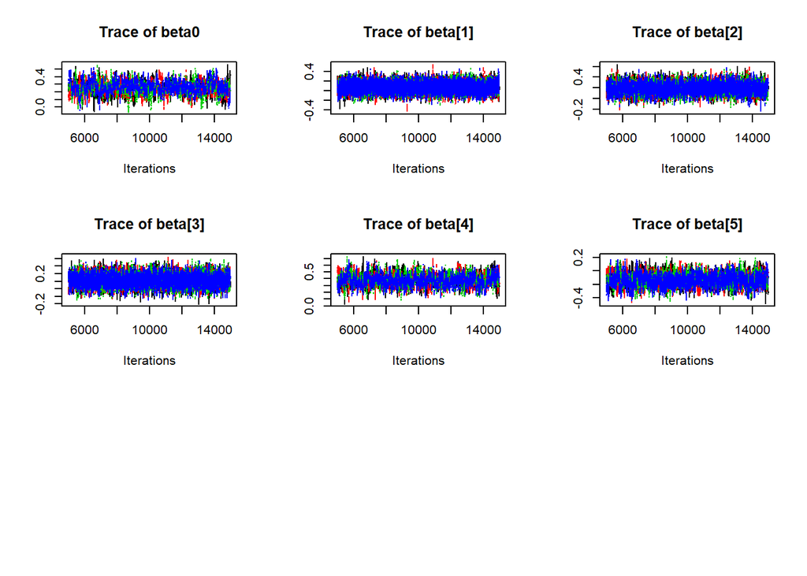

```r
par(mfrow = c(3,3))
traceplot(model_regBayes)
```

#### ii. Accuracy and stability

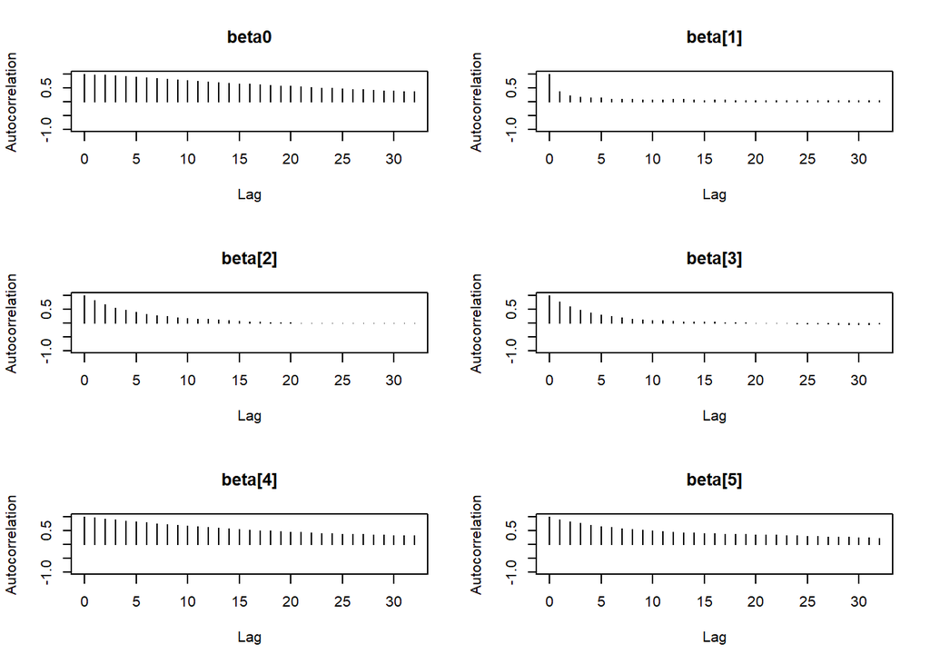

```r
# ACF Plot for first chain only
autocorr.plot(model_regBayes[[1]])
```

#### iii. Efficiency

94. When running our chains using **parallel computing** methods, it took 13.79 seconds which is a reasonable time.
95. From the **trace plots** in the *Chain Representativeness* section above, we can set our **burnin** for running our chains to 6,000. This allows us to get our $\beta_i$ parameters to settle to a stationary state faster, thereby improving our efficiency further.

### Interpreting regression model outputs

```r
summary(model_regBayes)$statistics
```

```
##                Mean         SD     Naive SE Time-series SE
## beta0    0.25350995 0.08737526 0.0004368763    0.003510420
## beta[1]  0.07773072 0.09838290 0.0004919145    0.001144821
## beta[2]  0.20038144 0.09961198 0.0004980599    0.001619133
## beta[3]  0.11570926 0.07692315 0.0003846158    0.001101476
## beta[4]  0.38415429 0.08833069 0.0004416534    0.002943096
## beta[5] -0.12889226 0.09276154 0.0004638077    0.002814757
```

### Regression model accuracy

97. The **RMSE** for our **Bayesian multi-linear regression** model is 0.15. As we have scaled our data to be in the range [0,1], then this is a small value, hence our model is accurate in predicting *Graduate Prospects 2018*.[^9]

### Credible interval

98. In the output below, we have the 95% **credible interval** for each of our independent variables. These values can be interpreted as follows:

> If we were to take one sample, there is a 95% probability that our parameter will lie within the region bounded by 2.5% and 97.5%.

```r
# Take C.I associated with first chain only
HPDinterval(obj = model_regBayes, prob = 0.95)[[1]]
```

```
##              lower     upper
## beta0    0.0599915 0.4096420
## beta[1] -0.1141650 0.2724460
## beta[2]  0.0157420 0.4023520
## beta[3] -0.0400820 0.2609500
## beta[4]  0.2000120 0.5666220
## beta[5] -0.3050260 0.0707685
## attr(,"Probability")
## [1] 0.95
```

## Comparing Bayesian with Frequentist Outputs

99. Below, we compare the summaries of our **multi-linear regression** models.

```r
model_regFreqSum
```

```
##
## Call:
## lm(formula = .outcome ~ ., data = dat)
##
## Residuals:
##      Min       1Q   Median       3Q      Max
## -0.44198 -0.08712  0.00567  0.07955  0.41216
##
## Coefficients:
##                             Estimate Std. Error t value  Pr(>|t|)
## (Intercept)                  0.25196    0.08945   2.817   0.00571 **
## `\\`EU to non-EU ratio\\``   0.07749    0.09681   0.800   0.42513
## `\\`Pass Fail ratio\\``      0.20204    0.09746   2.073   0.04040 *
## `\\`STEM non-STEM ratio\\``  0.11506    0.07713   1.492   0.13852
## `\\`Research Quality\\``     0.38478    0.08790   4.377 0.0000266 ***
## `\\`Stu-Staff Ratio\\``     -0.12663    0.09358  -1.353   0.17864
## ---
## Signif. codes:  0 '***' 0.001 '**' 0.01 '*' 0.05 '.' 0.1 ' ' 1
##
## Residual standard error: 0.1428 on 115 degrees of freedom
## Multiple R-squared:  0.4058, Adjusted R-squared:   0.38
## F-statistic: 15.71 on 5 and 115 DF,  p-value: 0.000000000009083
```

```r
model_regBayesSum
```

```
##
## Iterations = 5001:15000
## Thinning interval = 1
## Number of chains = 4
## Sample size per chain = 10000
##
## 1. Empirical mean and standard deviation for each variable,
##    plus standard error of the mean:
##
##             Mean      SD  Naive SE Time-series SE
## beta0    0.25351 0.08738 0.0004369       0.003510
## beta[1]  0.07773 0.09838 0.0004919       0.001145
## beta[2]  0.20038 0.09961 0.0004981       0.001619
## beta[3]  0.11571 0.07692 0.0003846       0.001101
## beta[4]  0.38415 0.08833 0.0004417       0.002943
## beta[5] -0.12889 0.09276 0.0004638       0.002815
##
## 2. Quantiles for each variable:
##
##              2.5%      25%     50%      75%   97.5%
## beta0    0.078920  0.19603  0.2534  0.31080 0.42942
## beta[1] -0.114835  0.01228  0.0779  0.14328 0.26956
## beta[2]  0.005905  0.13346  0.1999  0.26769 0.39575
## beta[3] -0.036210  0.06447  0.1160  0.16754 0.26712
## beta[4]  0.212285  0.32471  0.3847  0.44308 0.56059
## beta[5] -0.312104 -0.19096 -0.1287 -0.06696 0.05513
```

100. Below, we compare the **confidence/credible intervals** of each of our models.

```r
model_regFreqci
```

```
##                     2.5 % 97.5 %
## (Intercept)          0.07   0.43
## EU to non-EU ratio  -0.11   0.27
## Pass Fail ratio      0.01   0.40
## STEM non-STEM ratio -0.04   0.27
## Research Quality     0.21   0.56
## Stu-Staff Ratio     -0.31   0.06
```

```r
model_regBayesci
```

```
##              lower     upper
## beta0    0.0599915 0.4096420
## beta[1] -0.1141650 0.2724460
## beta[2]  0.0157420 0.4023520
## beta[3] -0.0400820 0.2609500
## beta[4]  0.2000120 0.5666220
## beta[5] -0.3050260 0.0707685
## attr(,"Probability")
## [1] 0.95
```

101. In our **frequentist multi-lienar regression**, our **RMSE** was 0.14, whereas in our **Bayesian multi-linear regression**, our **RMSE** was 0.15.

# Section 6: Next Steps

102. For text data cleaning, would like to investigate the *quanteda* package which is said to be more powerful, faster, and efficient than existing text analysis packages such as *tm*.
103. We have removed NAs from our datasets so that we can carry out the Bayesian analysis. With more time, we would like to use data imputation methods so that we do not lose data.
104. Use parallel computing methods for running caret. Exmaple can be found in documentation.
105. Run **Bayesian multi-linear regression** model with a uniform distribution as our *prior*.
106. Would like to analyse our **MCMC** chains more robustly by considering the **Gelman-Rubin stasitic and plots** for chain representativeness; check if our **multivariate effective sample size** is below our **minimum effective sample size**, and the **Monte Carlo Standard Error (MCSE)** for chain accuracy and stability,
107. Explore better ways to communicate this report, including **rmarkdown** slides and incorporating **rshiny** functionality to make the report and slides interactive.
108. Use **Mean Absolute Error (MAE)** isntead of **Root Mean Squared Error (RMSE)** as our metric for evaluating the performance of our **multi-linear regression** models because it is more interpretable. Also, each error influences **MAE** in direct proportion to the absolute value of the error, which is not the case for **RMSE**.
109. Complete *Glossary of Terms*.
110. Improve use of **Git** so that it big functionality/features added are committed to the central repo.
111. Investigate a plot highlighting differences in C.I. between **Bayesian** and **frequentist**.
112. Flesh out **GitHub** README.md file.
113. Experiment with transferring this markdown report into the R package, **bookdown**.
114. Try to get **pander** and **plotly** to work for pretty outputting of dataframes and plots in markdown.
115. Implement **continuous integration/deployment** as part of this.

# Section 7: Appendix

## Reproducible Analytical Pipeline (RAP)

116. This paper adopts RAP principles to ensure ease of reproducibility of analysis.
117. The underlying principle here is the belief that analysis should be reproducible, so that any analyst can take the code used here, and generate the same outputs with minimal manual engineering.
118. This ensures transparency and accountability of analysis as part of a wider framework of good quality-assurance and more effective knowledge management. Additionally, it allows the automation of publications such as SFRs within governments, which significantly reduces production time of publications, and ensuring more consistent quality.[^10]
119. For an amusing video that brings the benefits of RAP to life, see this Youtube clip [here](https://www.youtube.com/watch?v=s3JldKoA0zw).
120. Particular practices adopted to ensure alignment with RAP principles are:
     - **RProjects** | Creating a fixed R environment to work within and share, so that no computer-specific file directory is required.
     - **Lock-down version of packages** | Packages used have their versions locked down, so when major updates to packages are applied, these will not affect our results. This is acheived by the package, *packrat*.
     - **Modular coding** | Breaking down our code into modules based along the lines of data loading, data manipulation, data exploration, frequentist multi-linear regression and Bayesian multi-linear regression.
     - **Set random seed** | Specifying the random seed R uses to generate regression outputs so that we can obtain the same results.
     - **Version control** | Git is used to manage different versions of this analysis project, enabling dial-back to historical copies before a major change was made, and to enable collaborative working.
     - **Database/Web Extracts** | When data for analysis is taken from a live feed to an underlying database such as SQL, a copy of the data at that instance is made and saved within the *RProject* so that the record of the data when the analysis was performed is collected and used to reproduce results.[^11]

## Notes

121. The code shown within the HTML document is not the complete code used for this project. Instead, only the most interesting code will be displayed within the document. To see the complete code underlying this analysis, please refer to the *.rmd* file and *.R* scripts within the RProject.
122. The language, [LaTeX](http://www.statpower.net/Content/310/R%20Stuff/SampleMarkdown.html), was used to write mathematical functions and equations within the HTML report. In particular, the **LaTeX** code for **RMSE** was taken from inspecting the element (HTML code) on this [webpage from Standord](http://statweb.stanford.edu/~susan/courses/s60/split/node60.html).
123. Within the code scripts, the following naming conventions are used:
     - R scripts | camelCase
     - Dataframe objects | Prefixed with *data_*
     - User-created functions | Prefixed with *func_*
     - Temporary objects | Prefixed with *temp_*
     - Matrix objects | Prefixed with *mat_*
     - Vectors of names | Prefixed with *name_*
     - Model objects | Prefixed with *model_*
     - Variables | camelCase
     - Other objects for report | Prefixed with *rpt_*
     - String directly for report | Prefixed with *txt_*
124. The theme for this HTML document is *journal*. A list of alternative themes already included within the **rmarkdown** package can be found [here](https://rmarkdown.rstudio.com/html_document_format.html). For further themes to use, download the **prettydoc** package which gives you more [themes](https://cran.r-project.org/web/packages/prettydoc/vignettes/architect.html) to choose from.
125. The code highlighting for this HTML document is *haddock*. A further list of options can be found [here](https://eranraviv.com/syntax-highlighting-style-in-rmarkdown/).
126. The packages used in this analysis are:
- **packrat** | Locking-down versions of packages.
- **tidyverse** | Data import, manipulation, and plotting.[^12]
- **tm** | Cleaning text data.
- **SnowballC** | Stems text
- **stringdist** | Fuzzymatching text data.
- **rvest** | Scraping information from the web.
- **rmarkdown** | Generate HTML report within RStudio session.
- **caret** | General-purpose package to perform machine-learning, including **multi-linear regression** and **k-fold cross-validation**.
- **fitdistrplus** | Powerful distribution-plotting of data, enabling the selection of the best-fitting common distribution to your data.
- **runjags** | Facilitates Bayesian analysis as well as doing so efficiently via parallel processing.
- **coda** | Performs Markov-Chain Monte Carlo diagnostic checks for Bayesian analysis.

## Credits

127. The following people have influenced this report:
- **Richard Morey (Cardiff University)** | Bayesian statistics
- **Adam Robinson (DfE)** | RProjects, modular coding, packrat, continuous integration/deployment
- **Zachary Waller (DfE)** | Git
- **Callum Staff (DfE)** | RAP
- **David Goody (DfE)** | Fuzzy-matching
- **Salman Kasim (DfE)** | Web-scraping
- **Chris Thom (DfE)** | apply functions > loops
- **Michelle Clements (BEIS)** | Text data cleaning
- **Robert Jones (DfE)** | Clear naming of objects

# Section 8: Environment

128. This analysis was conducted on a laptop with the specifications and packages outlined below.
[^1]: *First-degree students* are defined as students taking their first undergraduate degree or professional qualification.
[^2]: One of the main reasons why **frequentist statistics** is the dominant mode of statistical thinking is due to computational power. Before recent advances, it was very difficult to efficiently perform **Bayesian statistics**. Another key reason is centred on a historical, epic, and longstanding [war](http://lesswrong.com/lw/774/a_history_of_bayes_theorem/) between **Frequentist** statisticians (*Ronald Fisher, Jerzy Neyman and Egon Pearson*) and **Bayesian** statisticians (*Thomas Bayes, Pierre-Simon Laplace*), which was won by the former group in the early 20th Century. 💥
[^3]: There can be cases where the two approaches lead to substantially different results.
[^4]: Example taken from [this StackExchange question](https://stats.stackexchange.com/questions/22/bayesian-and-frequentist-reasoning-in-plain-english). Another excellent Star Wars analogy of **Bayesian reasoning** can be found at the [countbayesie](https://www.countbayesie.com/blog/2015/2/18/hans-solo-and-bayesian-priors) website.
[^5]: Indeed, the fact that **Bayesian** inference is more intuitive was the subject of discussion in Daniel Kahnemann’s best-seller, *Thinking, Fast and Slow*.
[^6]: For a good webpage on how to interpret regression diagnostic plots, visit the [University of Virginia library’s webpage](http://data.library.virginia.edu/diagnostic-plots/).
[^7]: If we did not meet this assumption, we can **Box-Cox** transform our dependent variable to try and make it normally-distributed.
[^8]: One typically complements the use of the **goodness-of-fit plots** by computing recommended **goodness-of-fit statistics** such as the **Kolmogorov-Smirnov stastistic**, **Cramer-von Mises statistic**, or the **Anderson-Darling statistic**. They then use these statistics to test against the null hypothesis that the empirical (dependent variable) distribution fits an estimated (proposed) distribution. However, since these recommended **goodness-of-fit statistics** are available only for **maximum likelihood estimations**, then we cannot take this complimentary approach.
[^9]: Use **k-fold cross-validation** with 10-folds to compute the **RMSE** here. Code has been hidden because a custom function was created to compute this, and it is not immediately obvious that the function computes the **RMSE** as it returns several objects within a list.
[^10]: For more information on RAP, see this government blog [post](https://dataingovernment.blog.gov.uk/2017/03/27/reproducible-analytical-pipeline/).
[^11]: We do not have a live link to an underlying database in this project, but we have web-scraped HTML tables.
[^12]: This has now been removed as not all the packages in **tidyverse** are required, and when downloading these packages on a different workspace, we want to minimise the time it takes to download the required packages for this project. It has instead been replaced by the **tidyr**, **dplyr**, **ggplot2**, **readr**, **reshape2**, and **magrittr** packages.